# **Answers To Sales Data Analysis Project Business Questions**

We are going to answer the Business Questions required for this analysis and display the final report on Google slides.

## **Dataset Overview**

The dataset for this project includes the product names, ID, Date, Quantity, Price, Sales Volumes, and delivery Address of various products in various regions of United States of America in 2019.

### **1. How much money did we make this year?**

To answer this question we need to create a `total amount` column from `Quantity_Ordered` multiplied by `Price_Each` then aggregate the yearly sales and filter out the 2019 sales, our year of focus.

|  | Order_ID | Product | Quantity_Ordered | Price_Each | Order_Date | Purchase_Address | Product_level | City | Total_amount($) |
| --- | --- | --- | --- | --- | --- | --- | --- | --- | --- |
| 77714 | 215802 | Bose SoundSport Headphones | 1 | 99.99 | 2019-06-13 21:05:00 | 451 Lake St, San Francisco, CA 94016 | high-level product | San Francisco | 99.99 |
| 19510 | 159962 | AA Batteries (4-pack) | 1 | 3.84 | 2019-02-02 21:45:00 | 974 Sunset St, San Francisco, CA 94016 | basic level product | San Francisco | 3.84 |
| 49440 | 188723 | USB-C Charging Cable | 1 | 11.95 | 2019-04-17 14:55:00 | 169 Dogwood St, San Francisco, CA 94016 | basic level product | San Francisco | 11.95 |
| 62713 | 201435 | Lightning Charging Cable | 1 | 14.95 | 2019-05-29 19:47:00 | 667 Church St, Los Angeles, CA 90001 | basic level product | San Francisco | 14.95 |
| 82687 | 220594 | Lightning Charging Cable | 1 | 14.95 | 2019-06-06 18:28:00 | 50 Park St, Los Angeles, CA 90001 | basic level product | San Francisco | 14.95 |

```
'Answer: This year(2019) we made $16,513,581.68 from product sales'
```

### **2. Can we identify any seasonality in the sales?**

|  | Order_Date | Total_amount($) |
| --- | --- | --- |
| 0 | 1 | 9665 |
| 1 | 2 | 11956 |
| 2 | 3 | 15127 |
| 3 | 4 | 18256 |
| 4 | 5 | 16551 |
| 5 | 6 | 13534 |
| 6 | 7 | 467 |
| 7 | 8 | 411 |
| 8 | 9 | 404 |
| 9 | 10 | 675 |
| 10 | 11 | 604 |
| 11 | 12 | 823 |

### **3. What are our best and worst-selling products?**

|  | index | Product | Quantity_Ordered |
| --- | --- | --- | --- |
| 0 | 5 | AAA Batteries (4-pack) | 14697 |
| 1 | 4 | AA Batteries (4-pack) | 13210 |
| 2 | 15 | USB-C Charging Cable | 11311 |
| 3 | 12 | Lightning Charging Cable | 11060 |
| 4 | 17 | Wired Headphones | 9817 |
| 5 | 6 | Apple Airpods Headphones | 7448 |
| 6 | 7 | Bose SoundSport Headphones | 6377 |
| 7 | 2 | 27in FHD Monitor | 3640 |
| 8 | 18 | iPhone | 3331 |
| 9 | 3 | 34in Ultrawide Monitor | 2998 |
| 10 | 1 | 27in 4K Gaming Monitor | 2890 |
| 11 | 9 | Google Phone | 2695 |
| 12 | 13 | Macbook Pro Laptop | 2242 |
| 13 | 8 | Flatscreen TV | 2233 |
| 14 | 14 | ThinkPad Laptop | 1983 |
| 15 | 0 | 20in Monitor | 1915 |
| 16 | 16 | Vareebadd Phone | 1020 |
| 17 | 11 | LG Washing Machine | 339 |
| 18 | 10 | LG Dryer | 331 |

### **4. How do sales compare to previous months or weeks?**

To answer this question we will aggregate monthly sales throughout the year for monthly comparision and do a weekly aggregate for weekly comparision, we will as well graph a pair plot for the weekly, monthly and total sales variables to see the bivariate distribution of those sales.

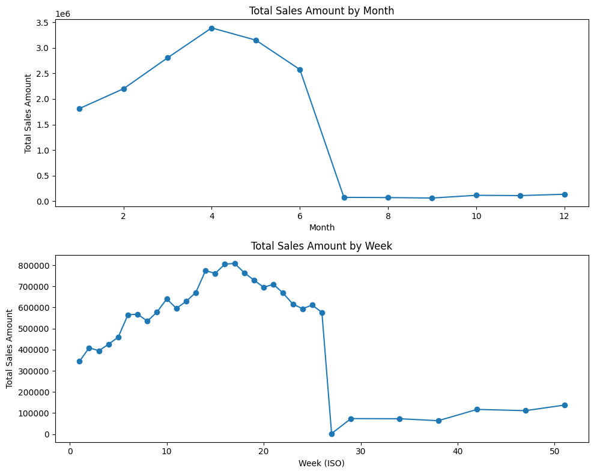

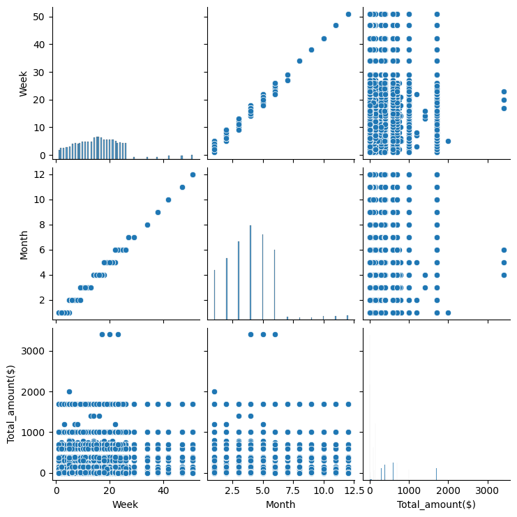

##### **Answer**

- According to the analysis of the data throughout the year 2019, the sales are high in the first half months of the year but they drop in the second half.
- When data is analysed weekly, there are flactuations in sales such that sometimes an increase is observed but, then followed by a slight dip in sales. This trend goes on for the first half of the year till week 26 where the trend takes a deep drop in sales then maintains lower sells volumes with slight changes through the rest of the year.

### **5. Which cities are our products delivered to most?**

```
City
San Francisco    35454
New York         11805
Dallas           11757
Boston            9389
Atlanta           7167
Seattle           6883
Portland          6018
Name: Quantity_Ordered, dtype: int64
```

##### **Answer**

- The City of `San Francisco` has the highest number of deliveries with a total of 35,454 deliveries whereas the City with the lowest number of deliveries is `Portland` with a total of 6,018 deliveries done in year 2019.

### **6. How do product categories compare in revenue generated and quantities ordered?**

We will aggregate product revenues and sales voules and compare them side by side on a table and a graph to illustrate the differences.

|  | Product | Quantity_Ordered | Total_amount($) |
| --- | --- | --- | --- |
| 13 | Macbook Pro Laptop | 2242 | 3.811400e+06 |
| 18 | iPhone | 3331 | 2.331700e+06 |
| 14 | ThinkPad Laptop | 1983 | 1.982980e+06 |
| 9 | Google Phone | 2695 | 1.617000e+06 |
| 3 | 34in Ultrawide Monitor | 2998 | 1.139210e+06 |
| 1 | 27in 4K Gaming Monitor | 2890 | 1.127071e+06 |
| 6 | Apple Airpods Headphones | 7448 | 1.117200e+06 |
| 8 | Flatscreen TV | 2233 | 6.699000e+05 |
| 7 | Bose SoundSport Headphones | 6377 | 6.376362e+05 |
| 2 | 27in FHD Monitor | 3640 | 5.459636e+05 |
| 16 | Vareebadd Phone | 1020 | 4.080000e+05 |
| 0 | 20in Monitor | 1915 | 2.106308e+05 |
| 11 | LG Washing Machine | 339 | 2.034000e+05 |
| 10 | LG Dryer | 331 | 1.986000e+05 |
| 12 | Lightning Charging Cable | 11060 | 1.653470e+05 |
| 15 | USB-C Charging Cable | 11311 | 1.351664e+05 |
| 17 | Wired Headphones | 9817 | 1.177058e+05 |
| 4 | AA Batteries (4-pack) | 13210 | 5.072640e+04 |
| 5 | AAA Batteries (4-pack) | 14697 | 4.394403e+04 |

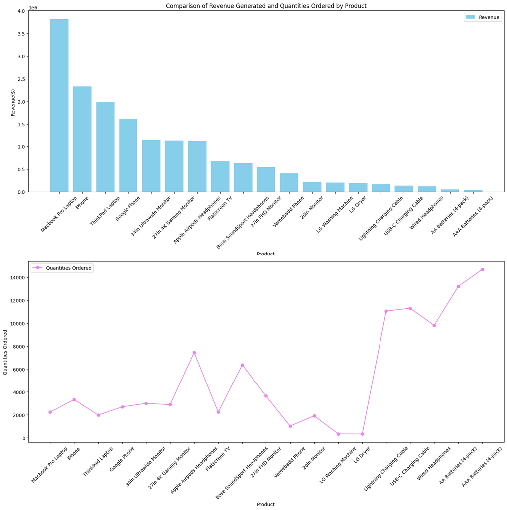

##### **Answer**

- The top 5 products with the highest order number shows that they are the ones with the least revenue generation and some products with the lowest order number indicates a better revenue generation.

### **7. Between the two levels which is the dominant product level?**

Aggregate the product count by the product level variable and plot pie chart to see the share of each category.

|  | Product_level | Count |
| --- | --- | --- |
| 0 | basic level product | 49450 |
| 1 | high-level product | 39023 |

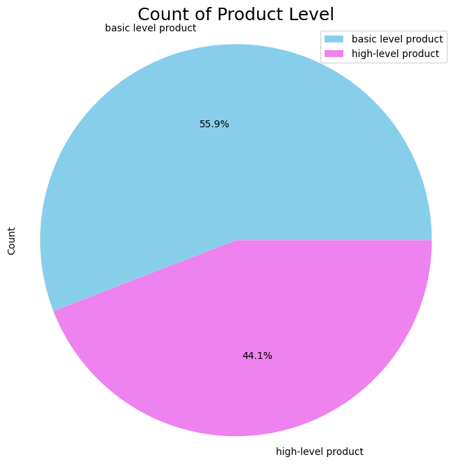

##### **Answer**

- The `basic level products` dominate the `high-level products` with a `55.9%`share of product relative to a `44.1%` share.